# Regression-Jonas

# Regression part I

The goal of a regression is to measure the relationship of 2 (or more) variables. It will be a challenge to find a graph the can fit the data points in our data set as good as possible. For my regression I decided to investigate the relationship of the Battery size to the range in kilometers. It is to be expected that I am going to try and prove my hypothesis that the bigger the battery is, the more kilometers the car can drive. The plan is to start simple by investigating the relationship of only 2 variable first, but it leaves the opportunity open to add more variables in the process. The first step is to import the data and essential libraries for this script:

```r
# install.packages("tidyverse")
# install.packages("gghighlight")
# install.packages("plyr")

library(tidyverse)
library(gghighlight)
library(plyr)
ev <- read_csv("/Users/jonasbrockmoller/Documents/GitHub/ElectricVehiclesEDA/Dataset/ElectricCarData_Clean_Me.csv")
ev
```

```
## # A tibble: 102 × 15
##    Brand      Model AccelSec TopSpeed_KmH Range_Km Battery_Pack_Kwh Efficiency_WhKm
##    <chr>      <chr>    <dbl>        <dbl>    <dbl>            <dbl>           <dbl>
##  1 Tesla      Mode…      4.6          233      460             70               161
##  2 Volkswagen ID.3…     10            160      270             45               167
##  3 Polestar   2          4.7          210      400             75               181
##  4 BMW        iX3        6.8          180      360             74               206
##  5 Honda      e          9.5          145      170             28.5             168
##  6 Lucid      Air        2.8          250      610            110               180
##  7 Volkswagen e-Go…      9.6          150      190             35.8             168
##  8 Peugeot    e-208      8.1          150      275             45               164
##  9 Tesla      Mode…      5.6          225      310             50               153
## 10 Audi       Q4 e…      6.3          180      400             77               193
## # … with 92 more rows, and 8 more variables: FastCharge_KmH <dbl>,
## #   RapidCharge <chr>, PowerTrain <chr>, PlugType <chr>, BodyStyle <chr>,
## #   Segment <chr>, Seats <dbl>, PriceEuro <dbl>
```

Above is the imported data shown contain information about all announced and released fully electric vehicles for the european and amarican market. In the following I am going to investigate the hypothesis about the relationship between the battery size and the range. In this dataset the battery size is given in KwH and the range is of type kilometers.

## 1. Show variables in a scatter plot (independent variable X = BatteryPack_size, depended variables Y = Range in km)

The following scatterplot shows the outliers in the dataset and the tibble will give additional details about these outliers:

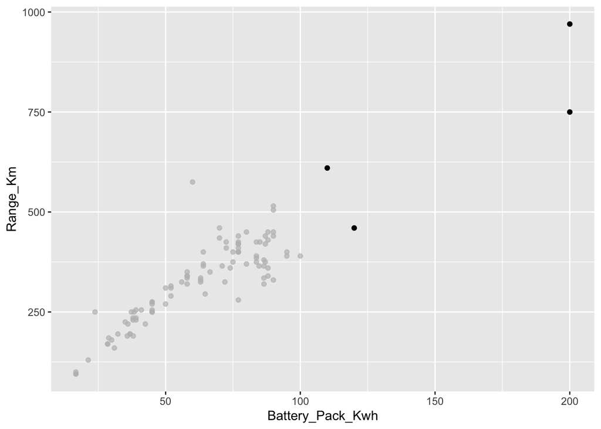

```r
  # Show outliers in the data in a scatter plot
  ggplot(ev, aes(x=Battery_Pack_Kwh, y=Range_Km)) + geom_point() + gghighlight(Battery_Pack_Kwh > 100)
```

```r
  # Show outliers in the data in form of a tibble
  outliers <- ev %>% filter(Battery_Pack_Kwh > 100)

  # Filter the undesired columns to only show a tible with relevant information
  undesiredColumns <- c('Segment', 'Seats', 'PlugType', 'PowerTrain', 'RapidCharge',   'FastCharge_KmH', 'Efficiency_WhKm',                'TopSpeed_KmH', 'AccelSec', 'PlugType')
  outliers <- outliers %>% select(-one_of(undesiredColumns))

  # Show the cleaned tibble
  outliers
```

```
## # A tibble: 4 × 6
##   Brand Model                 Range_Km Battery_Pack_Kwh BodyStyle PriceEuro
##   <chr> <chr>                    <dbl>            <dbl> <chr>         <dbl>
## 1 Lucid Air                        610              110 Sedan        105000
## 2 Tesla Cybertruck Tri Motor       750              200 Pickup        75000
## 3 Tesla Roadster                   970              200 Cabrio       215000
## 4 Tesla Cybertruck Dual Motor      460              120 Pickup        55000
```

As it can be seen above the outliers are either 100000€ or more supercars or the announced but not yet released cybertruck. The cybertruck will be equiped with a new type of battery and 120-200 KwH of capacity. These numbers are out of scope for this regression and would only make the result inaccurate so they are left out.

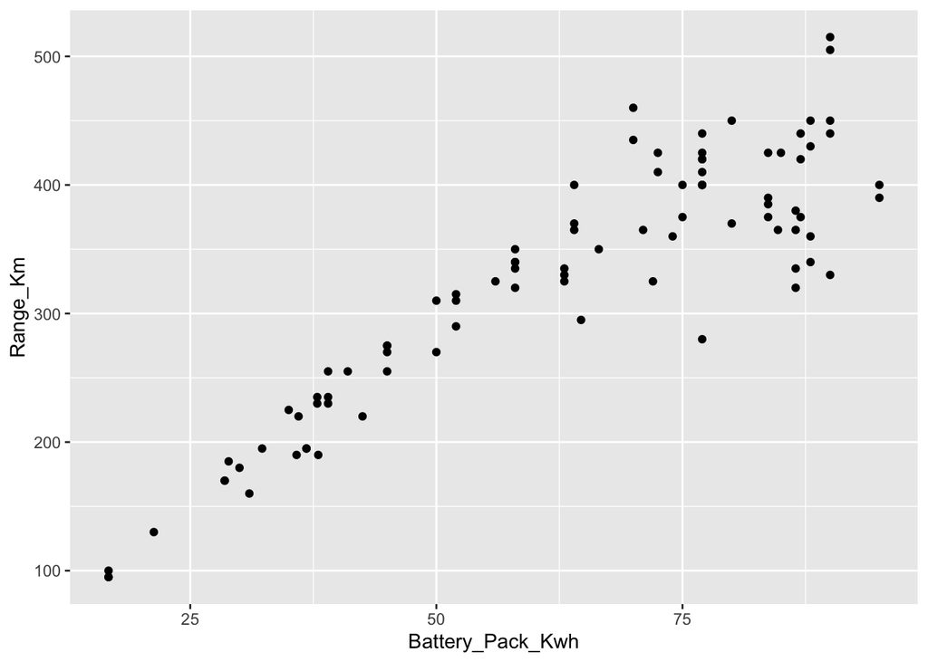

```r
  #Filter out exceptional data
  ev <- ev %>% filter(Battery_Pack_Kwh < 100)
  ev <- ev %>% filter(Range_Km < 550)
  ev <- ev %>% filter(Range_Km != 250)

  #Show a scatter plot with the cleaned dataset
  ggplot(ev, aes(x=Battery_Pack_Kwh, y=Range_Km)) + geom_point()
```

In this first step the relationship of the X-variable (BatteryPackSize) and the Y-Variable(Range in km) is presented based on the cleaned dataset. In addition the outliers have been found, investigated and removed.

## 2. lm()-Command, regression line and model summary

In the following the regression line will be visualized and a model is calculated.

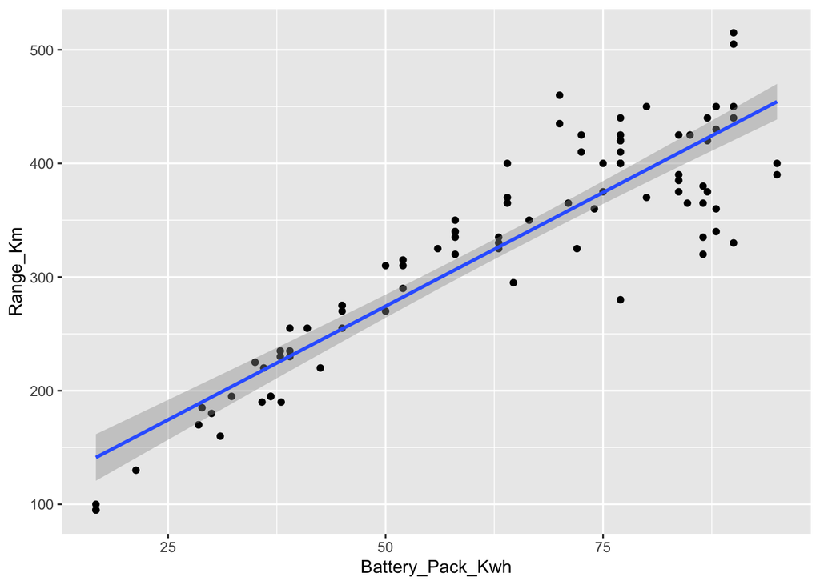

```r
  # Simple linear regression line on the scatter plot
  ggplot(ev, aes(x=Battery_Pack_Kwh, y=Range_Km)) + geom_point() + geom_smooth(method='lm', formula= y~x)
```

```r
  # Calculate simple regression model
  model <- lm(Range_Km ~ Battery_Pack_Kwh, data = ev)
  summary(model)
```

```
##
## Call:
## lm(formula = Range_Km ~ Battery_Pack_Kwh, data = ev)
##
## Residuals:
##      Min       1Q   Median       3Q      Max
## -104.338  -26.594    5.135   26.381  105.641
##
## Coefficients:
##                  Estimate Std. Error t value Pr(>|t|)
## (Intercept)       74.4328    13.4387   5.539 3.12e-07 ***
## Battery_Pack_Kwh   3.9989     0.2022  19.776  < 2e-16 ***
## ---
## Signif. codes:  0 '***' 0.001 '**' 0.01 '*' 0.05 '.' 0.1 ' ' 1
##
## Residual standard error: 41.96 on 88 degrees of freedom
## Multiple R-squared:  0.8163, Adjusted R-squared:  0.8142
## F-statistic: 391.1 on 1 and 88 DF,  p-value: < 2.2e-16
```

#### 4.1 Coefficients and regression model results

Shown above is the simple linear regression model. I feel inclined to say that the regression model is showing a kind of strong relationship between the 2 variables.

But lets review the regression results first: * The extremely low p-value (< 2e-16) is marked with *** which is the best possible case. In this test the Null-Hypothesis is being investigated. In this case the possibility that the battery pack size does NOT have a relationship with the range of an electric vehicle can be discarded. Luckily the result was well under 0.5 and because of this the Null-hypothesis can be rejected.

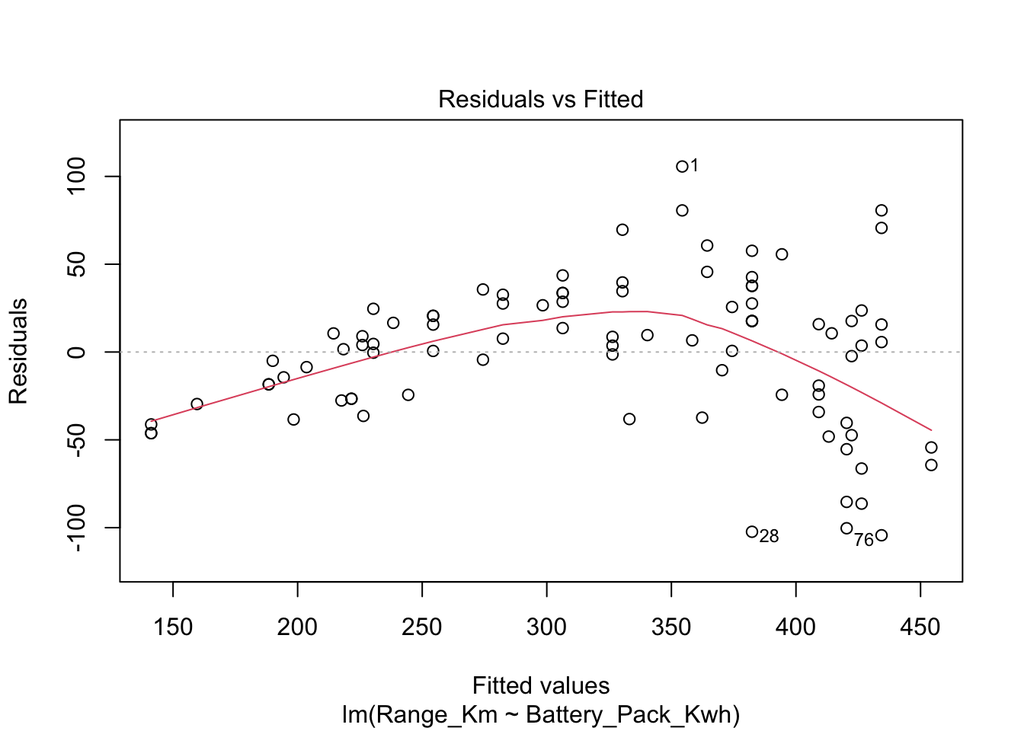

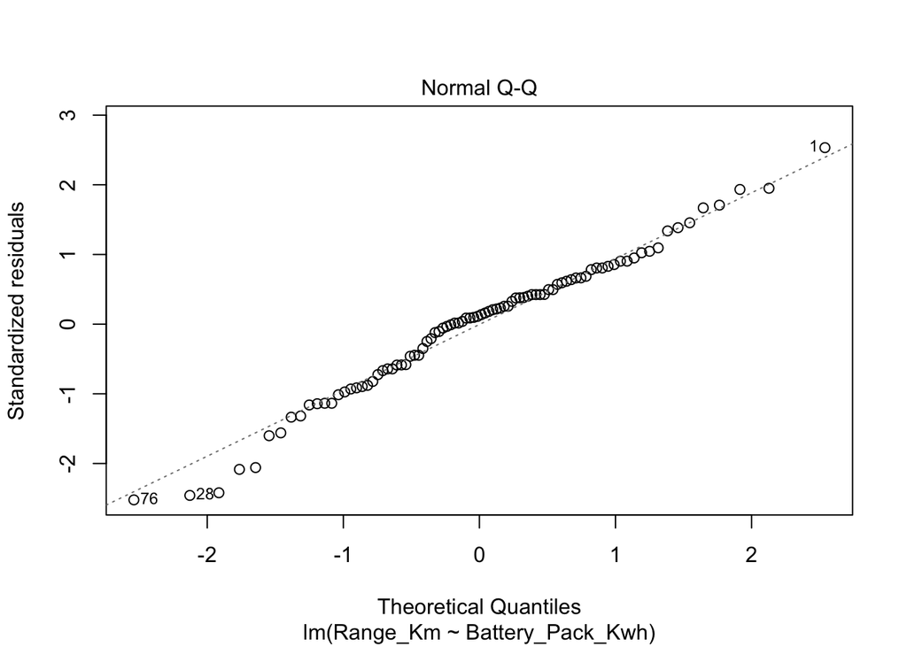

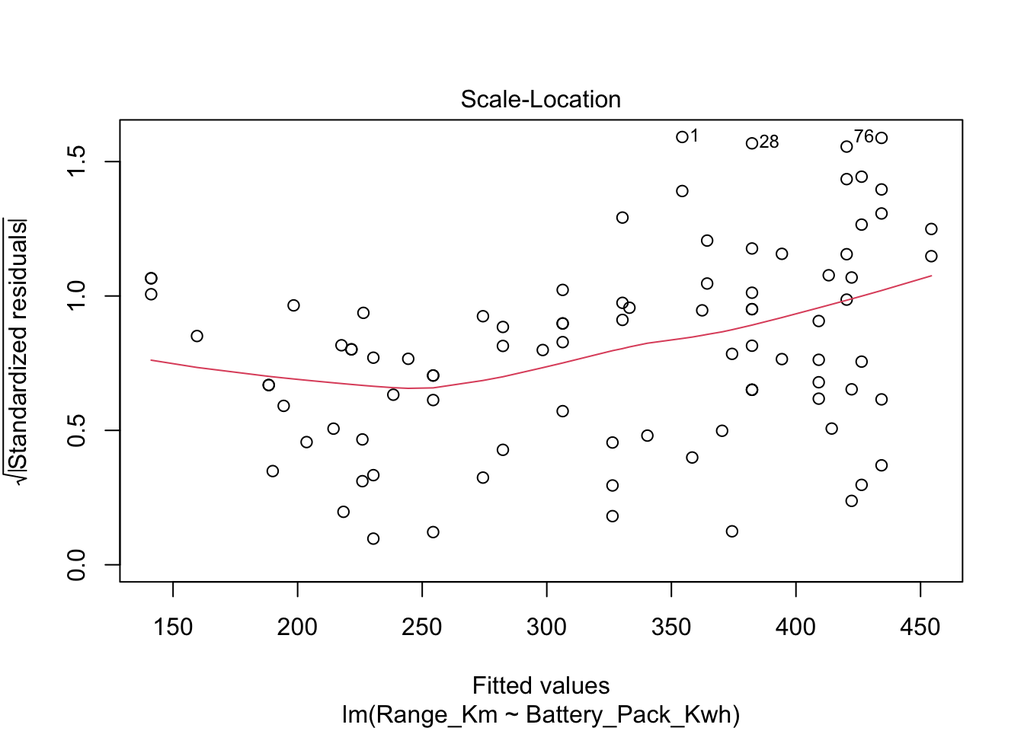

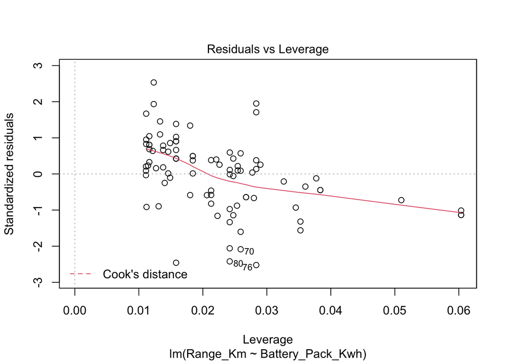

```r
 plot(model)
```

- The residuals vs. Fitted plots red line should be close to the perfect dotted grey line. But in this regression model it hints to an undiscovered quadratic relationship, because the graph proceeds curvlinear.
- The Normal Q-Q Graph shows good results for the regression. Only small deviations are visible in this model.
- The scale vs Location graph also hints at an undiscovered qudratic relationship, because of the curvilinear behavior of the red line.

# Regression part II

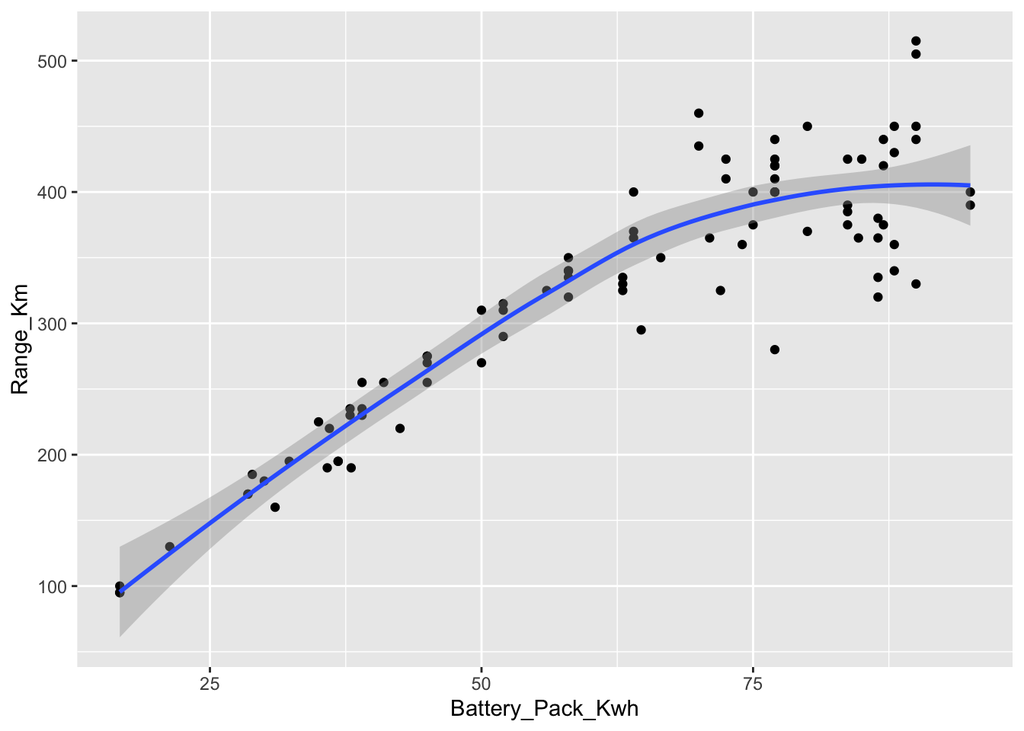

```r
  # Scatterplot with a quadratic geom smooth line
  ggplot(ev, aes(x=Battery_Pack_Kwh, y=Range_Km)) + geom_point() + geom_smooth(method='auto', formula= y~x)
```

The scatter plot above is based on the same dataset as before, but the regression line has been modified. I assume the relatioship is not of the simple linear type, but more of a quadratic relationship.

```r
  # Regression model for a quadratic relationship
  modelSqared <- lm(Range_Km ~ Battery_Pack_Kwh + I(Battery_Pack_Kwh^2), data = ev)

  summary(modelSqared)
```

```
##
## Call:
## lm(formula = Range_Km ~ Battery_Pack_Kwh + I(Battery_Pack_Kwh^2),
##     data = ev)
##
## Residuals:
##      Min       1Q   Median       3Q      Max
## -109.668  -23.226    3.628   18.264  105.028
##
## Coefficients:
##                         Estimate Std. Error t value Pr(>|t|)
## (Intercept)           -66.697092  29.302780  -2.276   0.0253 *
## Battery_Pack_Kwh        9.661276   1.091082   8.855 8.91e-14 ***
## I(Battery_Pack_Kwh^2)  -0.048500   0.009221  -5.259 1.02e-06 ***
## ---
## Signif. codes:  0 '***' 0.001 '**' 0.01 '*' 0.05 '.' 0.1 ' ' 1
##
## Residual standard error: 36.76 on 87 degrees of freedom
## Multiple R-squared:  0.8606, Adjusted R-squared:  0.8574
## F-statistic: 268.6 on 2 and 87 DF,  p-value: < 2.2e-16
```

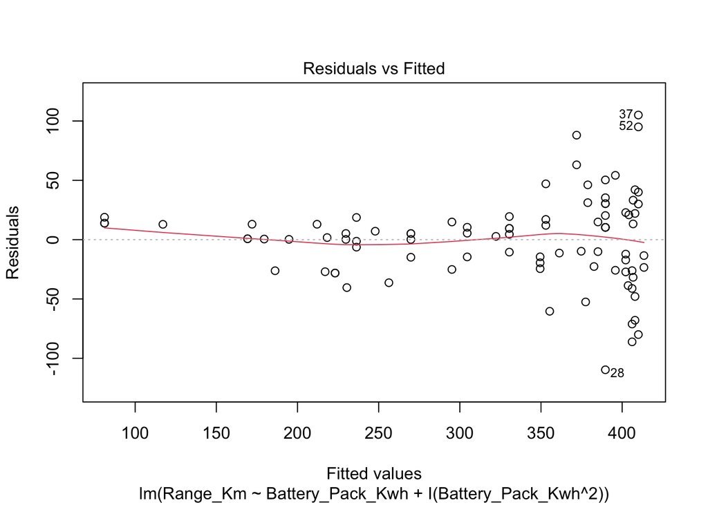

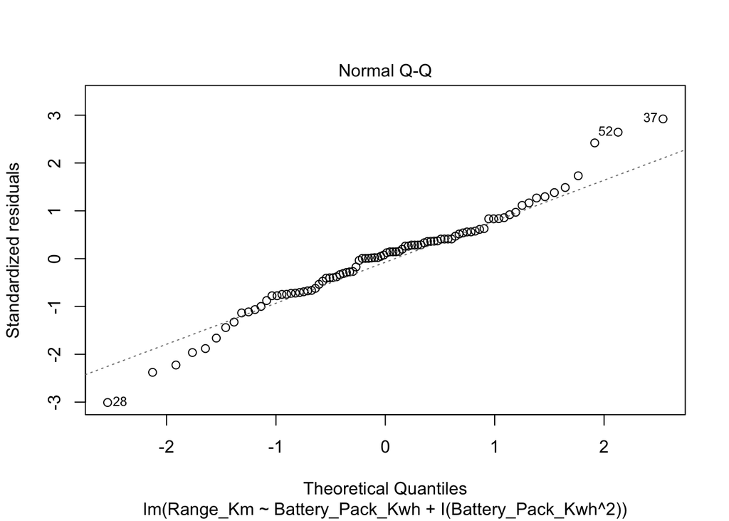

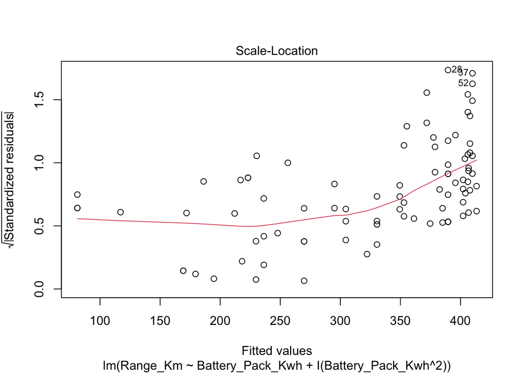

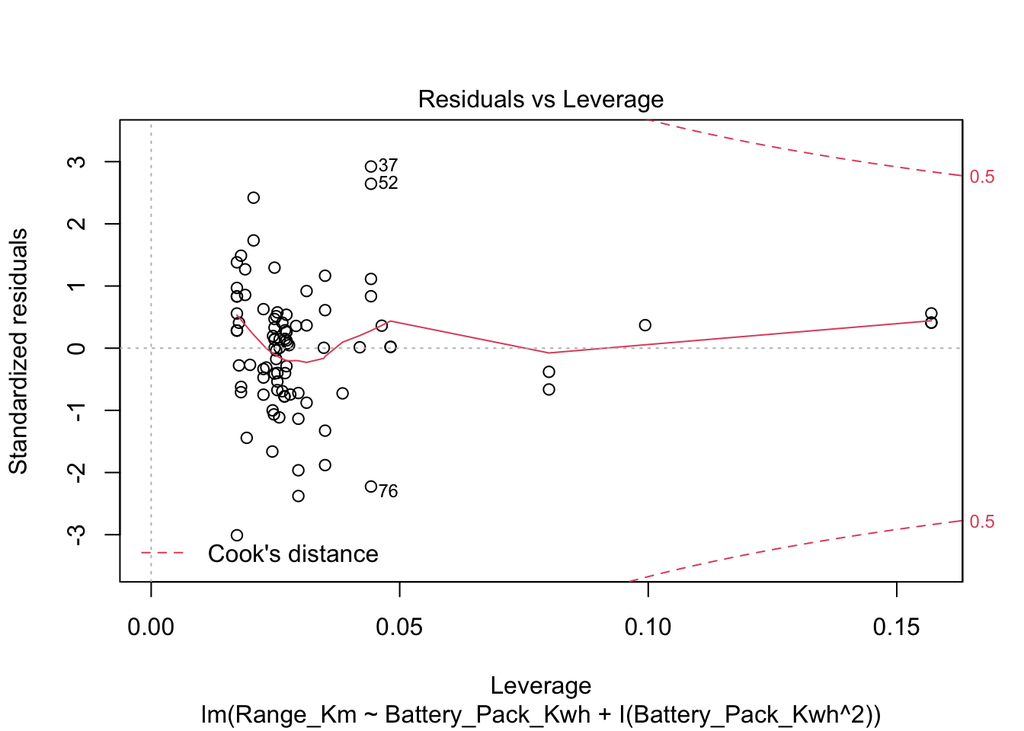

```r
  # par(mfrow=c(2,2))
  plot(modelSqared)
```

Because the this model is a multiple linear regression model the results cannot be descibed and interpreted anymore. This is the reason that the model results can only be compared on the numbers but not on the meaning.

```r
 #vif(modelSqared)
```

```r
  cor(ev$Battery_Pack_Kwh, I(ev$Battery_Pack_Kwh^2))
```

```
## [1] 0.9867316
```

This command chacks for correclation of 2 varaiables, because multivariate models make the assumption that all values are independent from each other. This means we have a structural correlation type here. Because of this the data cannot be read afterwards from the model. But the model can still fit the data very well. It makes it just hard to analyse the model.

# Multiple linear Regression with Bodystyle (categorical variable)

Looking at the results of the simple regression I’m thinking how the model can be improved. Using the efficiency as an additional variable makes no sense to me, because then the result can be calculated. This is not the type of relationship a regression should describe so I have decided to try building another model with the BatterySize and the BodyStyle as variables to determine the range. Since the BodyStyle is a categorical value the procedure for regressing is a bit different. Also the variable need to be independent from another and the model will not be describable in the end anymore.

```r
# This command produces a  tibble with the count of each bodystyle
count(ev, "BodyStyle")
```

```
##   BodyStyle freq
## 1    Cabrio    1
## 2 Hatchback   31
## 3  Liftback    3
## 4       MPV    1
## 5     Sedan    9
## 6       SPV    3
## 7   Station    1
## 8       SUV   41
```

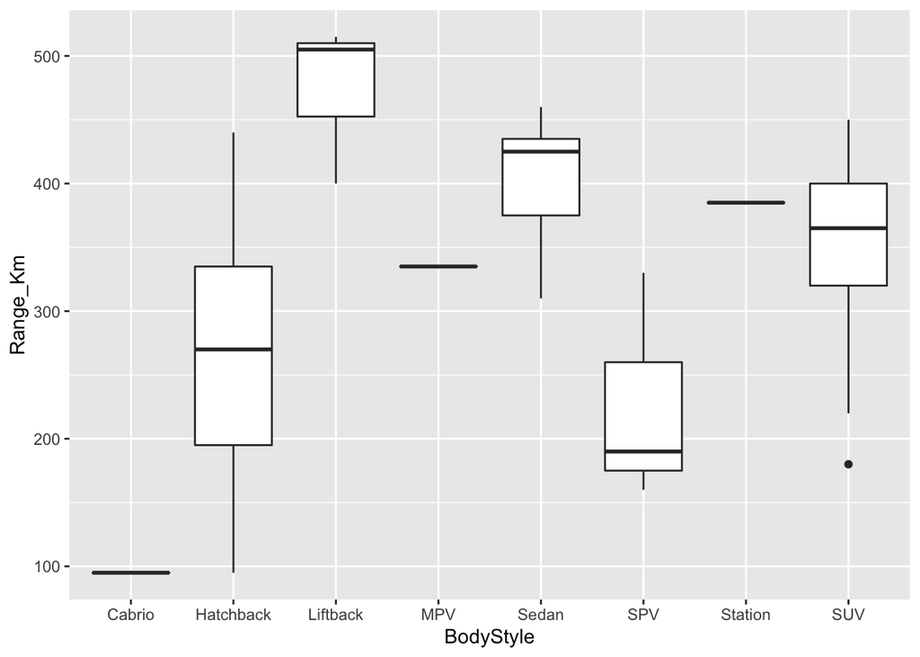

```r
# Plotting a boxsplot for each bodystyle to visualize the relationship
ggplot(ev, aes(x = BodyStyle, y = Range_Km)) +
  geom_boxplot()
```

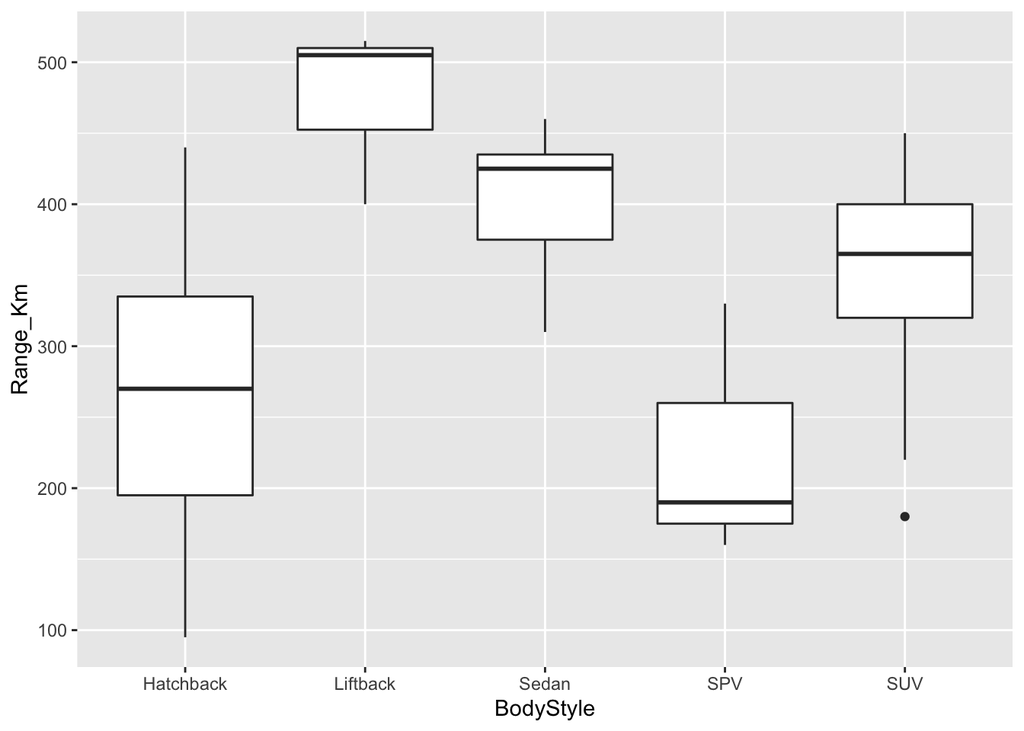

```r
# Cleaning the dataset for useful categories
usefulBodySyles <- ev
usefulBodySyles <- usefulBodySyles %>% filter(BodyStyle != 'MPV')
usefulBodySyles <- usefulBodySyles %>% filter(BodyStyle != 'Station')
usefulBodySyles <- usefulBodySyles %>% filter(BodyStyle != 'Cabrio')

# Plotting a boxsplot with the cleaned and useful dataset
ggplot(usefulBodySyles, aes(x = BodyStyle, y = Range_Km)) +
  geom_boxplot()
```

2. lm()-Command, summary(model) and plot(model2)

```r
  # Calculate a regression model for the cleaned dataset
  model2 <- lm(Range_Km ~ Battery_Pack_Kwh + I(Battery_Pack_Kwh^2) + BodyStyle, data = usefulBodySyles)
  summary(model2)
```

```
##
## Call:
## lm(formula = Range_Km ~ Battery_Pack_Kwh + I(Battery_Pack_Kwh^2) +
##     BodyStyle, data = usefulBodySyles)
##
## Residuals:
##    Min     1Q Median     3Q    Max
## -99.32 -16.29   0.14  20.68  63.23
##
## Coefficients:
##                         Estimate Std. Error t value Pr(>|t|)
## (Intercept)           -64.167447  29.002327  -2.212  0.02978 *
## Battery_Pack_Kwh        9.804328   1.076039   9.111 5.30e-14 ***
## I(Battery_Pack_Kwh^2)  -0.050453   0.008872  -5.687 2.04e-07 ***
## BodyStyleLiftback      71.180166  21.007010   3.388  0.00109 **
## BodyStyleSedan         21.856714  13.518253   1.617  0.10985
## BodyStyleSPV          -52.124872  19.752817  -2.639  0.01000 **
## BodyStyleSUV          -12.307940   9.044385  -1.361  0.17739
## ---
## Signif. codes:  0 '***' 0.001 '**' 0.01 '*' 0.05 '.' 0.1 ' ' 1
##
## Residual standard error: 32.49 on 80 degrees of freedom
## Multiple R-squared:  0.8927, Adjusted R-squared:  0.8846
## F-statistic: 110.9 on 6 and 80 DF,  p-value: < 2.2e-16
```

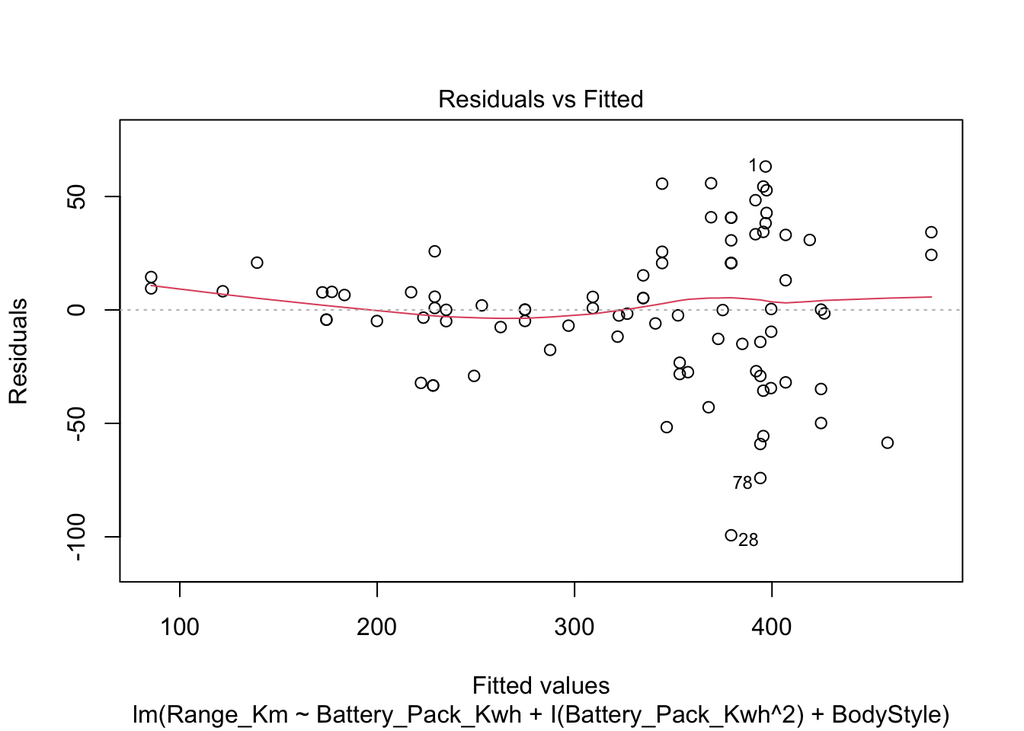

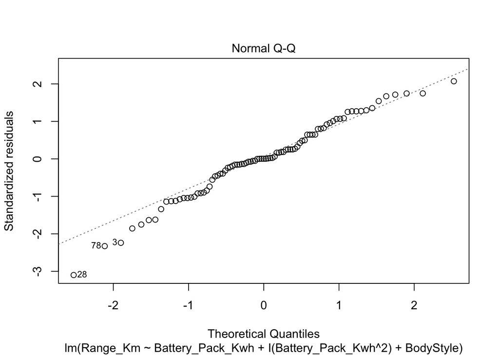

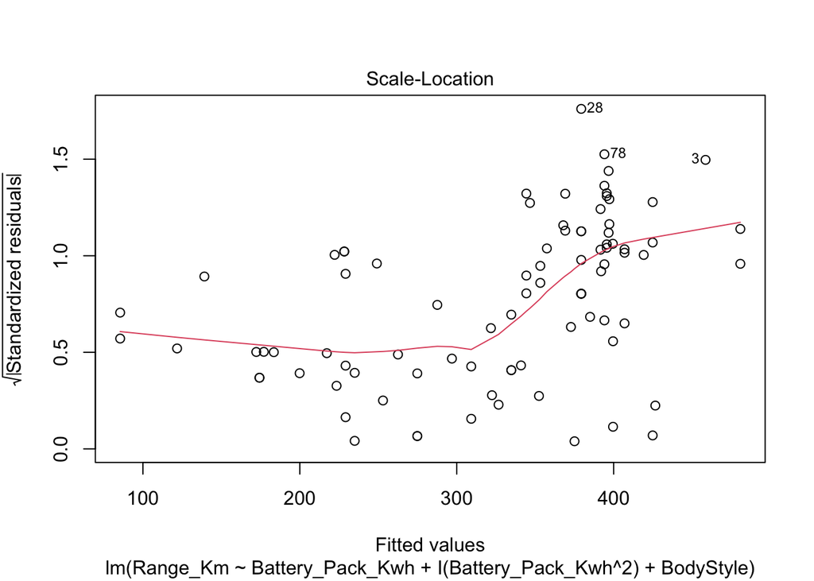

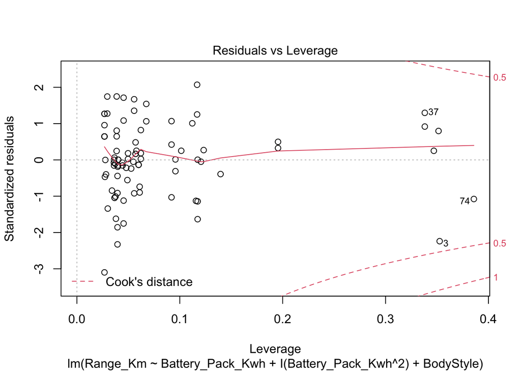

```r
  plot(model2)
```

```r
 # anova(model, model2)
```

# Multiple linear Regression with price (non-categorical variable)

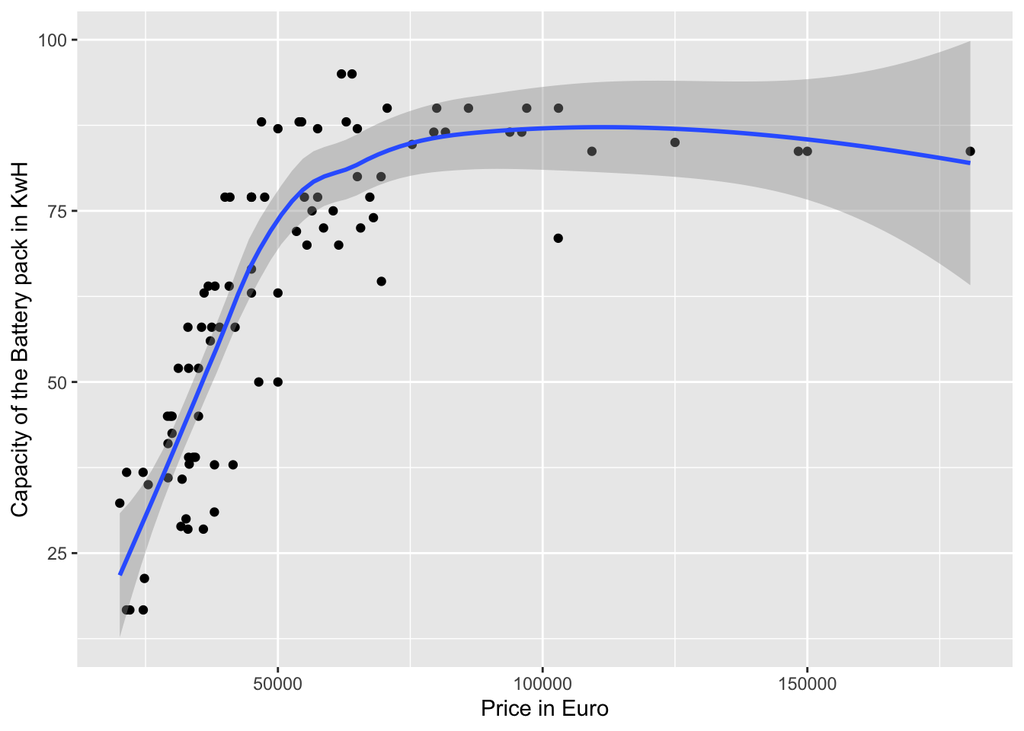

```r
  ggplot(ev, aes(x=PriceEuro,y=Battery_Pack_Kwh)) + geom_point() + geom_smooth(method='auto',level=0.95)+ labs(x = "Price in Euro", y = "Capacity of the Battery pack in KwH")
```

```r
  lmPrice <- lm(Battery_Pack_Kwh ~ PriceEuro + I(PriceEuro^2), data = ev)
  summary(lmPrice)
```

```
##
## Call:
## lm(formula = Battery_Pack_Kwh ~ PriceEuro + I(PriceEuro^2), data = ev)
##
## Residuals:
##      Min       1Q   Median       3Q      Max
## -25.5750  -7.9175  -0.4037   7.4226  25.2484
##
## Coefficients:
##                  Estimate Std. Error t value Pr(>|t|)
## (Intercept)    -3.499e+00  5.077e+00  -0.689    0.493
## PriceEuro       1.781e-03  1.483e-04  12.008  < 2e-16 ***
## I(PriceEuro^2) -7.859e-09  8.714e-10  -9.019  4.1e-14 ***
## ---
## Signif. codes:  0 '***' 0.001 '**' 0.01 '*' 0.05 '.' 0.1 ' ' 1
##
## Residual standard error: 11.81 on 87 degrees of freedom
## Multiple R-squared:  0.7183, Adjusted R-squared:  0.7119
## F-statistic: 110.9 on 2 and 87 DF,  p-value: < 2.2e-16
```

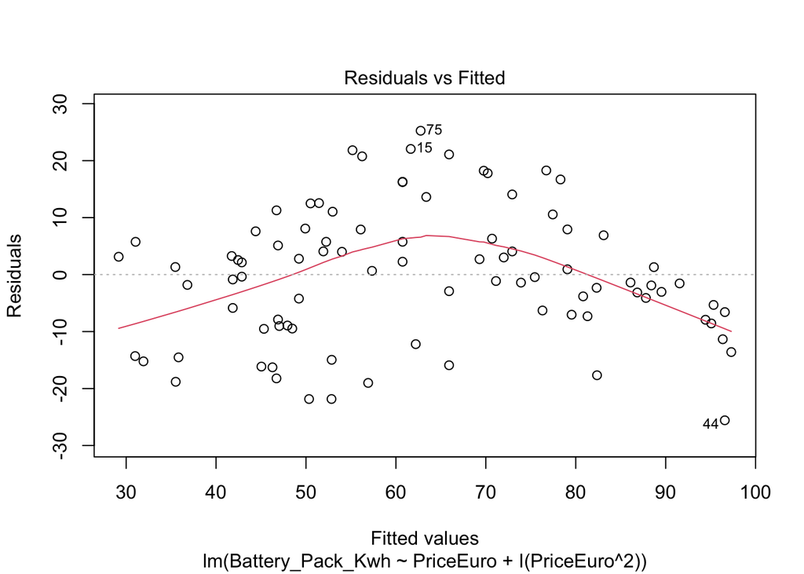

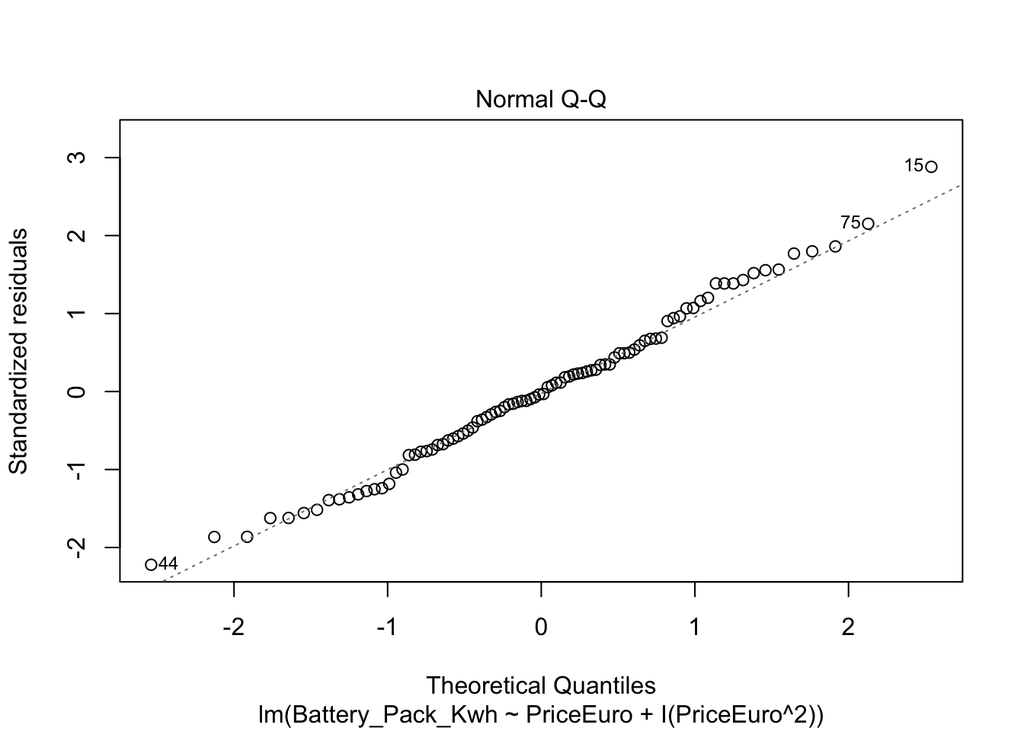

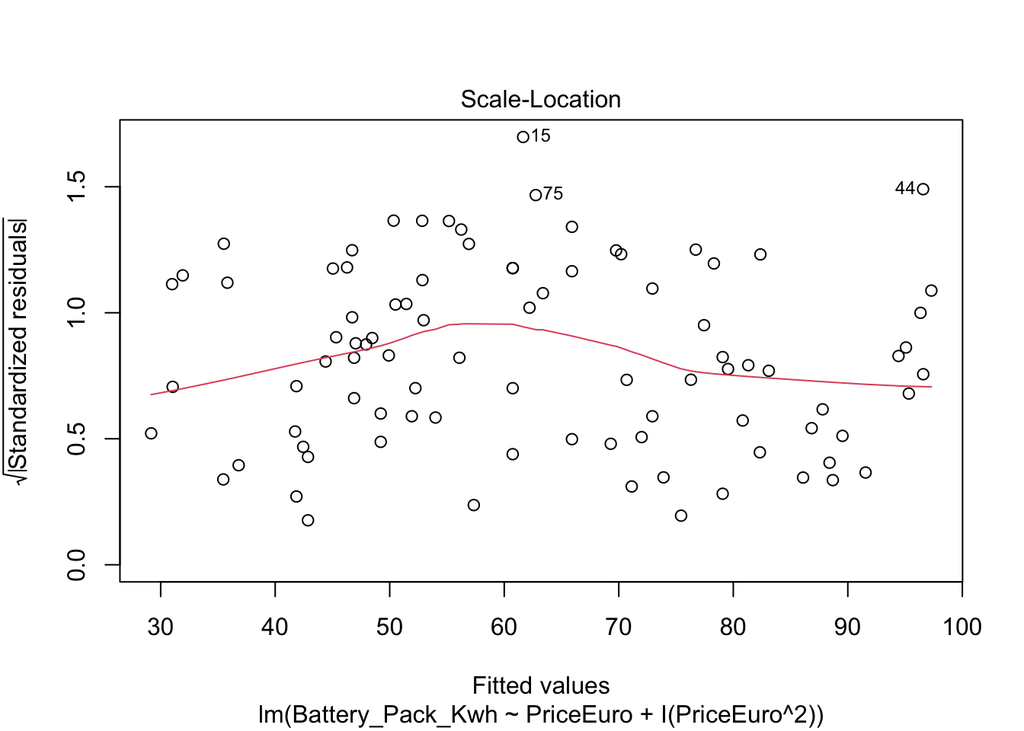

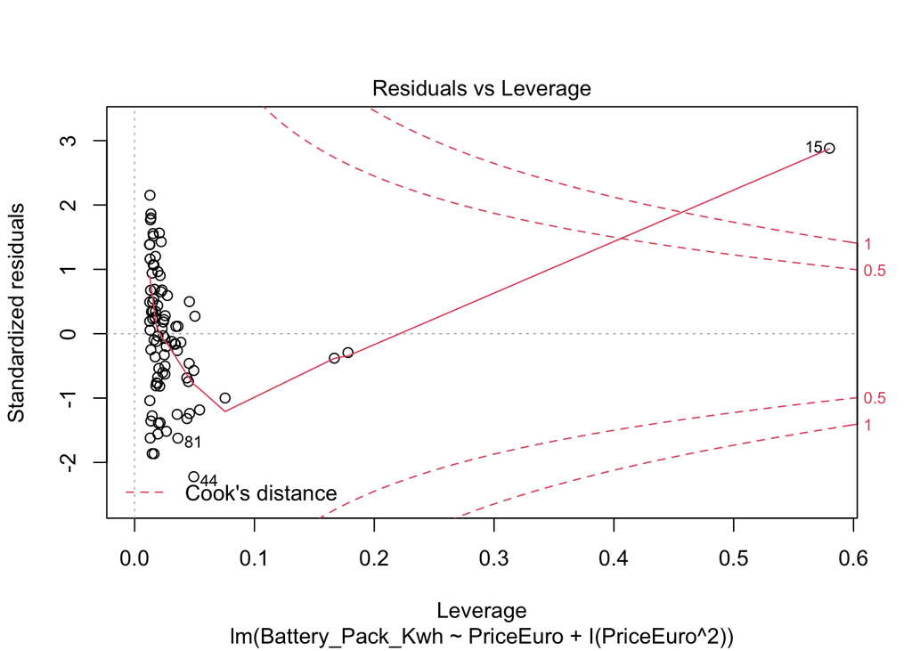

```r
  # par(mfrow=c(2,2))
  plot(lmPrice)
```

```r
#correlation and vif factor check for collinearity
cor(ev$Battery_Pack_Kwh, ev$PriceEuro)
```

```
## [1] 0.6745321
```

```r
# vif(lmPrice)
```